# Practice Problems 7

Solutions

# Part 0. Load Packages

Use the code chunk below to load any packages that you need for this assignment. Add `message = FALSE` to the top of your code chunk to hide the messages that print out when you load these packages.

```r
# you should have loaded these packages:
library(readr)
library(dplyr)
library(ggplot2)
library(ggmosaic)
library(broom)
```

> Make sure you added `message = FALSE` to the start of your code chunk.

# Part 1. Titanic Data

Answer the following questions about the `titanic.csv` dataset.

## Load Data in R

Enter code in the code chunk below to load the `titanic.csv` dataset into R. Make sure that you’ve downloaded the `.csv` file from Moodle and it’s saved in the same folder as this RMD. Add `message = FALSE` to the top of your code chunk to hide the messages that print out when you read in this data set.

```r
# read in Titanic dataset
titanic <- read_csv('../activities/titanic.csv')
```

> I have the `titanic.csv` dataset stored in a different folder than this RMD, so my code may look a little different from yours. If your CSV and RMD files are saved in the same folder, then the code will just be `titanic <- read_csv('titanic.csv')`.

> Make sure you added `message = FALSE` to the start of your code chunk.

## Data Viz

Create a data visualization that compares survival across 1st, 2nd, and 3rd class Titanic passengers.

> My preferred visualization here is a mosaic plot:

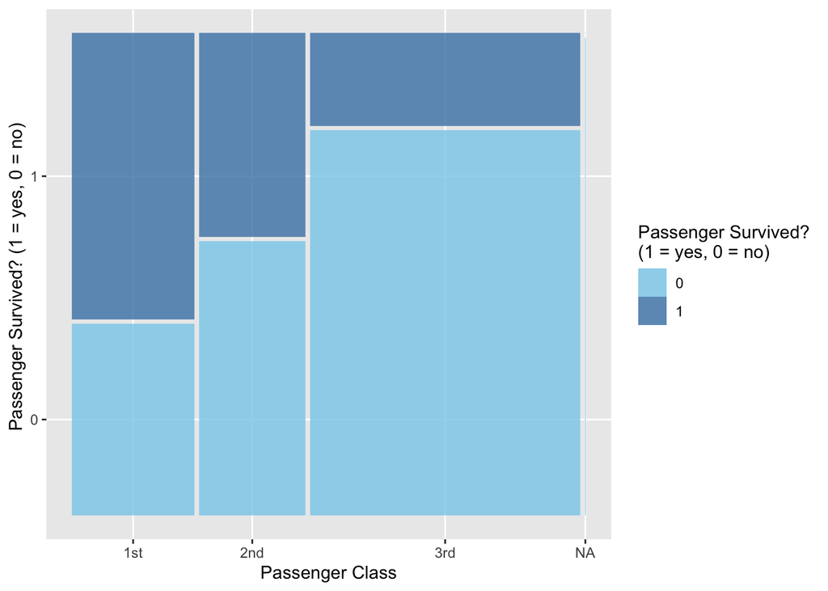

```r
titanic %>%
  ggplot() +
  geom_mosaic(aes(x = product(Survived, PClass), fill = Survived)) +
  xlab('Passenger Class') +
  ylab('Passenger Survived? (1 = yes, 0 = no) ') +
  scale_fill_manual('Passenger Survived?\n(1 = yes, 0 = no)', values = c("skyblue", "steelblue"))
```

Then, write a short description that summarizes the information gained from your plot. Write this summary using good sentences that tell a story about our research question (were passengers in 1st class more likely to survive the Titanic crash?) and do not resemble a checklist. Don’t forget to consider the context of the data.

> From the visualization, we notice a general trend that passengers were more likely to survive the higher their class. Over half of 1st class passengers on the Titanic survived, followed by a smaller proportion of 2nd class passengers, and an even smaller proportion of 3rd class passengers. This is particularly unfortunate given that 3rd class had the largest number of passengers.

## Linear Regression

Fit a linear regression model to these data, with `Survived` as the outcome and `PClass` as the predictor. Print out estimates for each of the coefficients in this model.

```r
# fit model
mod1 <- lm(Survived ~ PClass, data = titanic)

# print out coefficients
coef(mod1)
```

```
## (Intercept)   PClass2nd   PClass3rd
##   0.5993789  -0.1728556  -0.4052861
```

Write out an interpretation of each of the coefficients in your linear regression model:

> `(Intercept)`: the estimated probability of survival for passengers in 1st class is 0.599 (59.9%)

> `PClass2nd`: the difference in the estimated probability of survival comparing passengers in 1st class to passengers in 2nd class is 0.173 (17.3%), where passengers in 1st class have the higher estimated survival probability …OR… comparing passengers in 1st class to passengers in 2nd class, the difference in the proportion of passengers that survived is 0.173 (17.3%), with 1st class having a higher proportion of passengers that survived …OR… the probability of survival is 17.3% lower among passengers in 2nd class than it is among passengers in 1st class

> You should **not** be talking about averages in these interpretations: the average of a binary variable is the same as the probability that the binary variable equals one. It is best in this case to just talk about the probability of survival (`Survived = 1` means the person did in fact survive).

> Otherwise, make sure it is clear when interpreting the `PClass2nd` and `PClass3rd` coefficients that these represent differences in probabilities relative to passengers in 1st class (i.e., specify what your reference group is!).